# Lab 9

Author

Jack Brown

## Lab 9 - Generative Art

```r
library(ggplot2)
library(tibble)
library(dplyr)
library(usethis)
library(imager)
library(ggforce)
library(magick)
```

## Part 1

```r
sample_canva <- function(seed = NULL) {
  if(!is.null(seed)) set.seed(seed)
  sample(ggthemes::canva_palettes, 1)[[1]]
}
```

```r
sample_data <- function(seed = NULL, n = 100){
  if(!is.null(seed)) set.seed(seed)
  dat <- tibble(
    x0 = runif(n),
    y0 = runif(n),
    x1 = x0 + runif(n, min = -.2, max = .2),
    y1 = y0 + runif(n, min = -.2, max = .2),
    shade = runif(n),
    size = runif(n),
    shape = factor(sample(0:22, size = n, replace = TRUE))
  )
}
```

```r
polar_styled_plot <- function(data = NULL, palette) {
  ggplot(
    data = data,
    mapping = aes(
      x = x0,
      y = y0,
      xend = x1,
      yend = y1,
      colour = shade,
      size = size
    )) +
    coord_polar(clip = "off") +
    scale_y_continuous(
      expand = c(0, 0),
      limits = c(0, 1),
      oob = scales::oob_keep
    ) +
    scale_x_continuous(
      expand = c(0, 0),
      limits = c(0, 1),
      oob = scales::oob_keep
    ) +
    scale_colour_gradientn(colours = palette) +
    scale_size(range = c(0, 10)) +
    theme_void() +
    guides(
      colour = guide_none(),
      size = guide_none(),
      fill = guide_none(),
      shape = guide_none()
    )
}
```

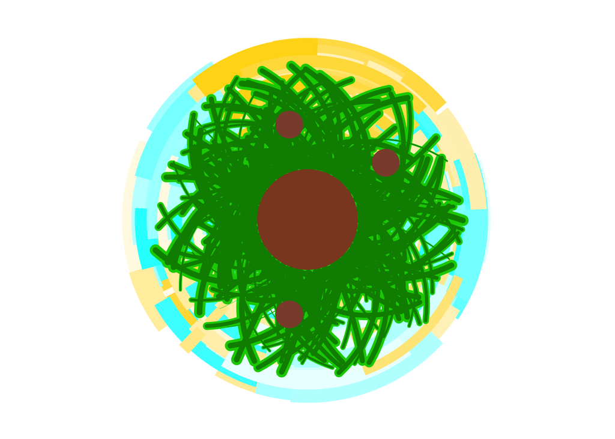

```r
dat1 <- sample_data(n = 500, seed = 123) |>
  mutate(y1 = y0, size = size / 2)

dat2 <- sample_data(n = 350, seed = 35) |>
  mutate(y0 = .3 + y0 * .6, y1 = .3)

dat3 <- as.data.frame(list(x1=0,y1=0))
dat4 <- as.data.frame(list(x1=-0.97,y1=-0.55))
dat5 <- as.data.frame(list(x1=0.97,y1=0.55))
dat6 <- as.data.frame(list(x1=0.15,y1=0.55))

polar_styled_plot(palette = c("cyan", "white", "gold")) +
  geom_segment(data = dat1) +
  geom_segment(data = dat1 |> mutate(y1 = y1 - .2, y0 = y0 - .2)) +
  geom_segment(data = dat1 |> mutate(y1 = y1 - .4, y0 = y0 - .4)) +
  geom_segment(
    data = dat2 |> mutate(size = size / 10),
    lineend = "round",
    colour = "green3"
  ) +
  geom_segment(
    data = dat2 |> mutate(size = size / 40),
    lineend = "round",
    colour = "green4"
  )  + geom_point(data=dat3, aes(x1,y1), size = 38, col="sienna4") +
  geom_point(data=dat4, aes(x1,y1), size = 10, col="salmon4") +
  geom_point(data=dat5, aes(x1,y1), size = 10, col="salmon4") +
  geom_point(data=dat6, aes(x1,y1), size = 10, col="salmon4")
```

**360 Bird’s Eye View of a Palm Tree on the Beach (with Three Coconuts):** This piece of digital art offers a modern and contemporary take on a rather ordinary sight for a California kid: a palm tree on the beach. The perspective is from a bird’s eye view, looking directly down on the palm tree from the top of it. It is also reminiscent of the view one would get when using a 360 degree camera, in which it wraps the entire picture to make everything look circular and around, as if you were on top of the world.

I combined several different elements of the examples using the polar_styled_plot() command provided in the generative art article, and then really just tried to combine them all. Once combined, I mainly changed the parameter n to a smaller number (to 500 from 2000) to get a less hectic and busy base of sand and water. I also changed the divisor in the size parameter in the mutate() function for dat1 and dat2 to try to obtain the best looking palm leaves. Finally, I of course altered the colors to mimic the golden sand and light blue water of the beach, as well as the dark green colors of palm tree laeves. I then made my own dataset “dat3” to add a simple brown circle in the middle using geom_point that acts as the center trunk/stem of the palm tree. Although probably not the most concise way, I also made separate datasets and geom_point() commands to add three coconuts to the palm tree. I honestly don’t love the way the coconuts look, but I just added them for fun and for more practice. :)

## Part 2

```r
library(rayshader)
library(tibble)
library(ambient)
library(dplyr)
library(ggplot2)
library(ggthemes)
library(tictoc)
library(dplyr)
```

```r
is_within_circle <- function(x_coord, y_coord, x_center, y_center, radius) {
  (x_coord - x_center)^2 + (y_coord - y_center)^2 < radius^2
}
```

```r
additive_circles <- function(n = 5, pixels = 1000, seed = NULL) {

  if(!is.null(seed)) set.seed(seed)

  # setup canvas
  art <- long_grid(
    x = seq(0, 1, length.out = pixels),
    y = seq(0, 1, length.out = pixels)
  )
  art$paint <- 50

  for(i in 1:n) {

    # sample a random circle
    x_center <- runif(1, min = .1, max = .9)
    y_center <- runif(1, min = .1, max = .9)
    radius <- runif(1, min = .005, max = .05)

    # add +1 to all points inside the circle
    art <- art |>
      mutate(
        paint = paint + is_within_circle(
          x, y, x_center, y_center, radius
        )
      )
  }

  # normalise paint to [0, 1] range and return
  art$paint <- normalise(art$paint)
  return(art)
}
```

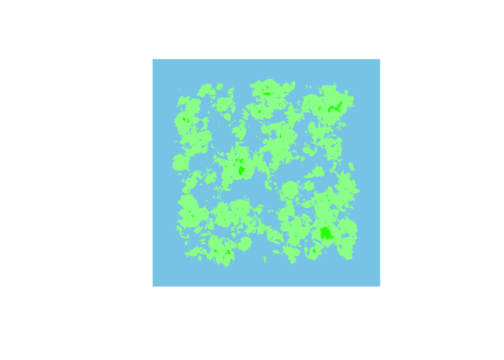

```r
circle_art <- additive_circles(1500, seed = 2)

circle_array <- circle_art |>
  as.array(value = paint)

circle_array |>
  image(axes = FALSE, asp = 1, useRaster = TRUE, col=c("skyblue", "palegreen", "green"))
```

**The Hidden Lands of the Flat Earth**: A completely random and baseless rendering that mimics the completely random and baseless belief that some hold that the Earth is flat. Believers of a Flat Earth have shared images very similar to this one, which supposedly is a map of the “real” Earth, displaying has “Hidden Lands”, which are tons of different groups of continents, separated by ice walls, which can be seen below.

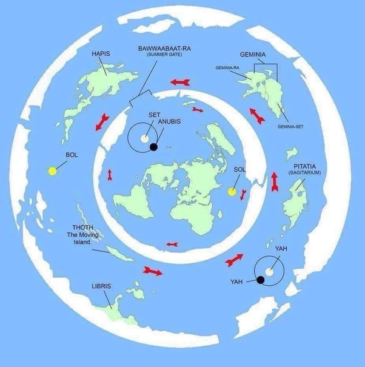

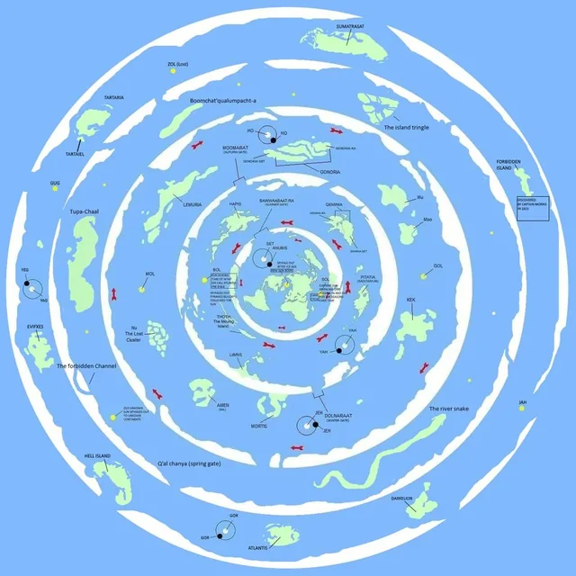

This art is made by rendering lots of circles using the additive_circles() command, and coloring the positive, negative, and overlapping space. I didn’t deliberately aim to make this 1x1 plot look like the Hidden Lands of the Flat Earth, but once I saw the output, it reminded me of it. The code started as just 5 large circles, overlapping in a random and boring way. Instead of only a few large circles, I wanted to create tons of very small circles, originally thinking I could maybe make it looks like a cluster of stars or supernova in space, but it looked kinda boring. I changed the code to allow the radius of the circles to range from between 0.005 and 0.05 (much smaller than the default), and allowed the (x,y) coordinates of centers of each circle range from anywhere from 0.1 to 0.9 (much bigger range than the default), so they could get much closer to the edge. I then continued to change the seed number until I found a rendering of the random circles that I liked.

I also tried my best to use ChatGPT to help me add a white swirl to the plot to represent the ice walls, but whenever I output the image, the original circle_array graph becomes “airbrushed” and less detailed.

```r
# Save the background image using the png package
png("background3.png", width = 1000, height = 1000)
image(
    x = seq(0, 1, length.out = 1000),
     y = seq(0, 1, length.out = 1000),
     z = t(circle_array),
     col = colorRampPalette(c("skyblue", "palegreen", "green"))(256),
     axes = FALSE,
     asp = 1
 )
dev.off()
```

```
# A tibble: 1 × 7
  format width height colorspace matte filesize density
  <chr>  <int>  <int> <chr>      <lgl>    <int> <chr>
1 PNG     1000   1000 sRGB       TRUE         0 72x72
```

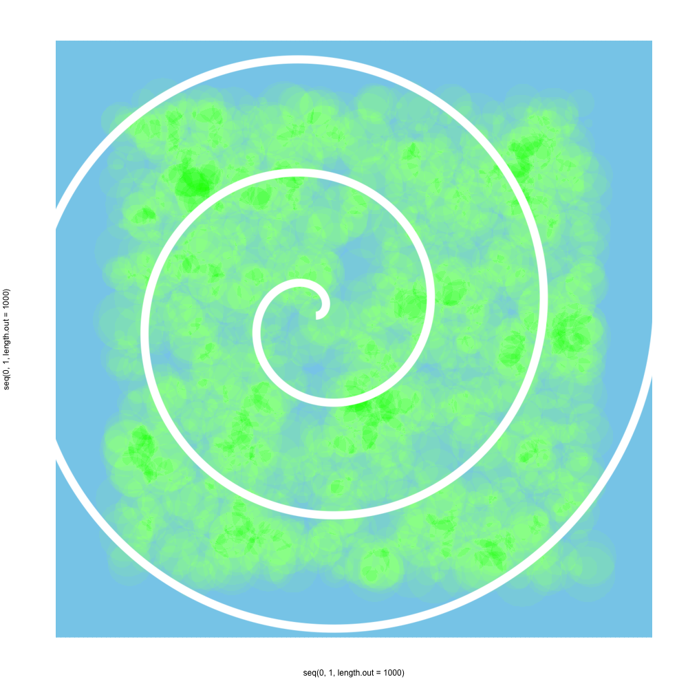

```r
# Generate the white swirl
num_points <- 1000  # Number of points in the swirl
turns <- 3          # Number of turns in the swirl
theta_max <- 2 * pi * turns

# Generate the swirl dataset
swirl_data <- data.frame(
  theta = seq(0, theta_max, length.out = num_points),
  r = seq(0, 1, length.out = num_points)
)

# Convert polar coordinates to Cartesian coordinates
swirl_data <- swirl_data %>%
  mutate(
    x = r * cos(theta),
    y = r * sin(theta)
  )

# Plot the swirl using ggplot2
swirl_plot <- ggplot(swirl_data, aes(x, y)) +
  geom_path(color = "white", size = 2) + # Draw a white path
  theme_void() +                         # Remove all background elements
  theme(
    panel.background = element_rect(fill = "transparent", color = NA),  # Transparent background
    plot.background = element_rect(fill = "transparent", color = NA)
  ) +
  coord_fixed() # Keep aspect ratio fixed

# Save the swirl plot as a PNG with a transparent background
ggsave("white_swirl.png", swirl_plot, width = 5, height = 5, bg = "transparent")

# Read the background and swirl images using magick
background <- image_read("background3.png")
swirl <- image_read("white_swirl.png")

# Resize the swirl to match the background size
swirl <- image_resize(swirl, geometry_size_pixels(width = 1000, height = 1000))

# Combine the images by overlaying the swirl on the background
combined_image <- image_composite(background, swirl, operator = "over")

# Save the combined image
image_write(combined_image, "combined_image.png")

# Display the combined image
print(combined_image)
```